# Multiomics Analysis Report

Aymen Maqsood

2025-01-12

# Computational Analysis of Single-Cell RNA and ATAC Sequencing Data

## Introduction

### Chromatin Accessibility and Gene Expression Correlation

Chromatin accessibility governs gene regulation by facilitating transcription factor binding and RNA polymerase recruitment. By integrating ATAC-seq (chromatin accessibility) and RNA-seq (gene expression) data, we aim to uncover how structural changes in chromatin correlate with transcriptional activity, offering insights into the regulatory dynamics of aging HSCs.

## Methodology

### Loading Libraries

```r
library(Signac)
library(Seurat)
```

### Data Source

The dataset, accessible via GEO (GSE190424), comprises high-resolution single-cell ATAC-seq and RNA-seq data from young and aged HSCs. This analysis builds on the research by Itokawa et al. (2022) in Nature Communications (“Epigenetic traits inscribed in chromatin accessibility in aged hematopoietic stem cells,” DOI: 10.1038/s41467-022-30374-9, PMID: 35577813). The ATAC-seq peak count matrix and metadata were imported using the *Read10X_h5* function.

```r
counts <- Read10X_h5("~/Desktop/Projects/V1.0/single_cell/data/GSM5723631_Young_HSC_filtered_peak_bc_matrix.h5")
meta <- read.csv("~/Desktop/Projects/V1.0/single_cell/data/GSM5723631_Young_HSC_singlecell.csv.gz", header = TRUE, row.names = 1)
```

### Preprocessing ATAC-seq Data

A *ChromatinAssay* object was created to process the ATAC-seq data, filtering for peaks present in at least 10 cells and cells with a minimum of 200 peaks.

```r
chrom_assay <- CreateChromatinAssay(
  counts = counts,
  sep = c(":", "-"),
  genome = "mm10",
  fragments = "~/Desktop/Projects/V1.0/single_cell/data/GSM5723631_Young_HSC_fragments.tsv.gz",
  min.cells = 10,
  min.features = 200
)
```

```
Computing hash
Checking for 5028 cell barcodes
```

```r
data <- CreateSeuratObject(counts = chrom_assay, assay = "peaks", meta.data = meta)
```

### Genome Annotation

Genomic annotations were added using the EnsDb.Mmusculus.v79 package to map peaks to genes and regulatory elements.

```r
library(GenomeInfoDb)
library(EnsDb.Mmusculus.v79)
annotations <- GetGRangesFromEnsDb(ensdb = EnsDb.Mmusculus.v79)
```

[output not shown]

```r
seqlevelsStyle(annotations) <- "UCSC"
Annotation(data) <- annotations
```

### Quality Control

I computed several quality metrics to assess data fidelity:

Nucleosome Signal: Ratio of mononucleosome to nucleosome-free fragments. TSS Enrichment: Enrichment of reads at transcription start sites. Blacklist Ratio: Proportion of reads in blacklisted regions. Percentage Reads in Peaks: Fraction of reads mapping to peak regions.

```r
data <- NucleosomeSignal(object = data)
```

[output not shown]

```r
data <- TSSEnrichment(object = data, fast = FALSE)
```

```
Extracting TSS positions
Finding + strand cut sites
Finding - strand cut sites
Computing mean insertion frequency in flanking regions
Normalizing TSS score
```

```r
data$blacklist_ratio <- data$blacklist_region_fragments / data$peak_region_fragments
data$pct_reads_in_peaks <- data$peak_region_fragments / data$passed_filters * 100
```

### Violin plot to visualise qc

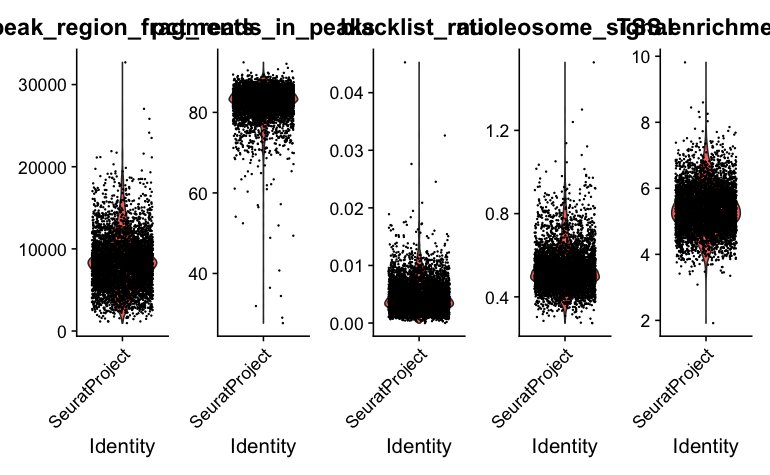

```r
VlnPlot(
  object = data,
  features = c("peak_region_fragments", "pct_reads_in_peaks", "blacklist_ratio", "nucleosome_signal", "TSS.enrichment"),
  pt.size = 0.1,
  ncol = 5
)
```

Visual inspection via violin plots revealed data quality distributions

- Cells were filtered based on stringent quality thresholds to exclude low-fidelity data:

#### Subsettign data to exclude low-fidelity data

```r
data <- subset(
  x = data,
  subset = peak_region_fragments > 3000 &
           peak_region_fragments < 20000 &
           pct_reads_in_peaks > 15 &
           blacklist_ratio < 0.05 &
           nucleosome_signal < 4 &
           TSS.enrichment > 2
)
```

*Quantile-based thresholds to enhance data robustness*

```r
low_prf <- quantile(data[["peak_region_fragments"]]$peak_region_fragments, probs = 0.02)
hig_prf <- quantile(data[["peak_region_fragments"]]$peak_region_fragments, probs = 0.98)
low_prp <- quantile(data[["pct_reads_in_peaks"]]$pct_reads_in_peaks, probs = 0.02)
high_blr <- quantile(data[["blacklist_ratio"]]$blacklist_ratio, probs = 0.98)
hig_ns <- quantile(data[["nucleosome_signal"]]$nucleosome_signal, probs = 0.98)
low_ts <- quantile(data[["TSS.enrichment"]]$TSS.enrichment, probs = 0.02)

data <- subset(
  x = data,
  subset = peak_region_fragments > low_prf &
           peak_region_fragments < hig_prf &
           pct_reads_in_peaks > low_prp &
           blacklist_ratio < high_blr &
           nucleosome_signal < hig_ns &
           TSS.enrichment > low_ts
)
```

### Normalisation and Dimensionality Reduction

Data were normalized using *TF-IDF*, followed by singular value decomposition (*SVD*) for dimensionality reduction, and *UMAP* for visualization. Clustering was performed using a *graph-based approach*.

```r
data <- RunTFIDF(data)
```

```
Performing TF-IDF normalization
```

```r
data <- FindTopFeatures(data, min.cutoff = "q0")
data <- RunSVD(data)
```

```
Running SVD
Scaling cell embeddings
```

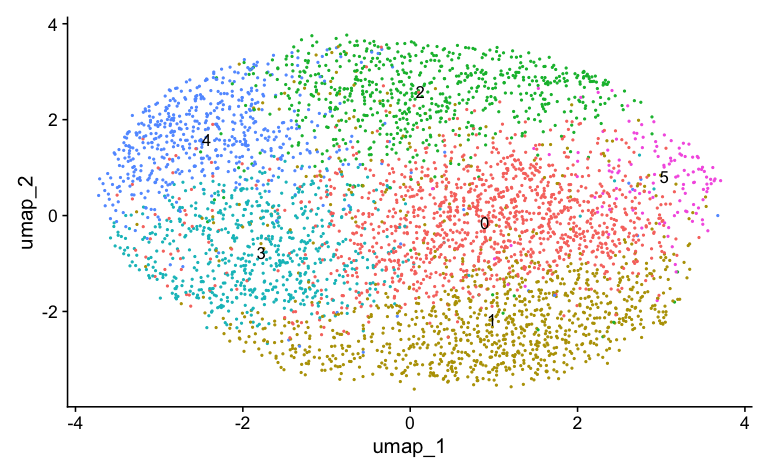

```r
data <- RunUMAP(object = data, reduction = "lsi", dims = 2:30)
data <- FindNeighbors(object = data, reduction = "lsi", dims = 2:30)
data <- FindClusters(object = data, verbose = FALSE, algorithm = 3)
DimPlot(object = data, label = TRUE) + NoLegend()
```

### Merging Young and Aged HSC Data

- A custom function, import_atac, was defined to import and preprocess ATAC-seq data from young and aged HSCs, followed by merging the datasets.

```r
import_atac <- function(count_path, meta_path, fragment_path) {
  counts <- Read10X_h5(filename = count_path)
  meta <- read.csv(file = meta_path, header = TRUE, row.names = 1)
  chrom_assay <- CreateChromatinAssay(
    counts = counts,
    sep = c(":", "-"),
    genome = "mm10",
    fragments = fragment_path,
    min.cells = 10,
    min.features = 200
  )
  data <- CreateSeuratObject(counts = chrom_assay, assay = "peaks", meta.data = meta)
  Annotation(data) <- annotations
  data <- NucleosomeSignal(object = data)
  data <- TSSEnrichment(object = data, fast = FALSE)
  data$blacklist_ratio <- data$blacklist_region_fragments / data$peak_region_fragments
  data$pct_reads_in_peaks <- data$peak_region_fragments / data$passed_filters * 100

  low_prf <- quantile(data[["peak_region_fragments"]]$peak_region_fragments, probs = 0.02)
  hig_prf <- quantile(data[["peak_region_fragments"]]$peak_region_fragments, probs = 0.98)
  low_prp <- quantile(data[["pct_reads_in_peaks"]]$pct_reads_in_peaks, probs = 0.02)
  high_blr <- quantile(data[["blacklist_ratio"]]$blacklist_ratio, probs = 0.98)
  hig_ns <- quantile(data[["nucleosome_signal"]]$nucleosome_signal, probs = 0.98)
  low_ts <- quantile(data[["TSS.enrichment"]]$TSS.enrichment, probs = 0.02)

  data <- subset(
    x = data,
    subset = peak_region_fragments > low_prf &
             peak_region_fragments < hig_prf &
             pct_reads_in_peaks > low_prp &
             blacklist_ratio < high_blr &
             nucleosome_signal < hig_ns &
             TSS.enrichment > low_ts
  )
  return(data)
}
```

### Importing and Merging Data

```r
young <- import_atac(
  "~/Desktop/Projects/V1.0/single_cell/data/GSM5723631_Young_HSC_filtered_peak_bc_matrix.h5",
  "~/Desktop/Projects/V1.0/single_cell/data/GSM5723631_Young_HSC_singlecell.csv.gz",
  "~/Desktop/Projects/V1.0/single_cell/data/GSM5723631_Young_HSC_fragments.tsv.gz"
)
```

[output not shown]

```r
old <- import_atac(
  "~/Desktop/Projects/V1.0/single_cell/data/GSM5723632_Aged_HSC_filtered_peak_bc_matrix.h5",
  "~/Desktop/Projects/V1.0/single_cell/data/GSM5723632_Aged_HSC_singlecell.csv.gz",
  "~/Desktop/Projects/V1.0/single_cell/data/GSM5723632_Aged_HSC_fragments.tsv.gz"
)
```

[output not shown]

### Merging Young and Aged HSC Data

```r
young$dataset <- "young"
old$dataset <- "old"
data <- merge(young, old)
```

[output not shown]

[output cut: 1905 more lines]

[output not shown]

- Post-merging, the dataset underwent additional normalization and clustering:

```r
data <- FindTopFeatures(data, min.cutoff = "q0")
data <- RunTFIDF(data)
```

```
Performing TF-IDF normalization
```

```r
data <- RunSVD(data)
```

```
Running SVD
Scaling cell embeddings
```

```r
data <- RunUMAP(object = data, reduction = "lsi", dims = 2:30)
```

```
Using method 'umap'
```

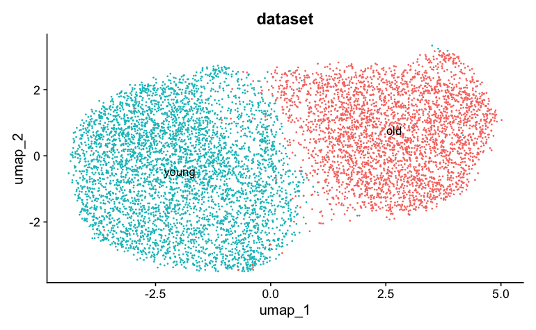

```r
data <- FindNeighbors(object = data, reduction = "lsi", dims = 2:30)
data <- FindClusters(object = data, verbose = FALSE, algorithm = 3, resolution = 0.4)
DimPlot(object = data, label = TRUE, group.by = "dataset") + NoLegend()
```

## Data Analysis

### Gene Activity integration

Gene activity scores, derived from ATAC-seq peaks, were computed as a proxy for transcriptional potential and integrated as an RNA assay.

```r
gene.activities <- GeneActivity(data)
```

```
Extracting gene coordinates
Extracting reads overlapping genomic regions
```

[output not shown]

```
Extracting reads overlapping genomic regions
```

[output not shown]

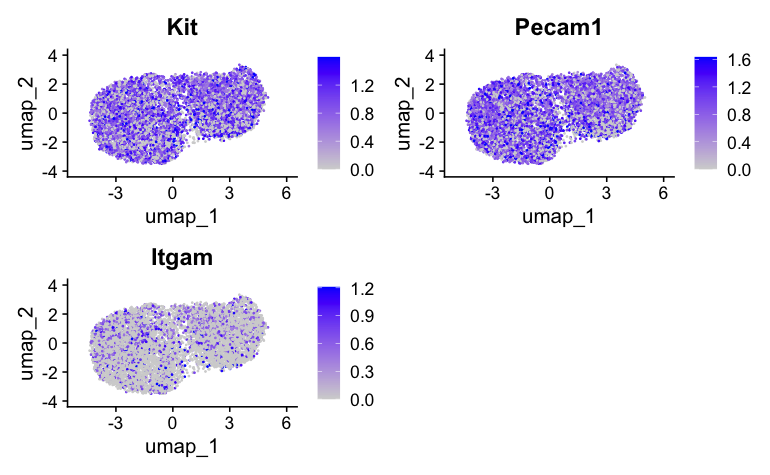

```r
data[["RNA"]] <- CreateAssayObject(counts = gene.activities)
data <- NormalizeData(
  object = data,
  assay = "RNA",
  normalization.method = "LogNormalize",
  scale.factor = median(data$nCount_RNA)
)
DefaultAssay(data) <- "RNA"
FeaturePlot(
  object = data,
  features = c("Kit", "Pecam1", "Itgam"),
  max.cutoff = "q95"
)
```

### Differential Accessibility Analysis

Differentially accessible regions (DARs) between young and aged HSCs were identified using a logistic regression test, with peak region fragments as a latent variable.

```r
DefaultAssay(data) <- "peaks"
da_peaks <- FindMarkers(
  object = data,
  ident.1 = rownames(data[[]][data$dataset == "old", ]),
  ident.2 = rownames(data[[]][data$dataset == "young", ]),
  min.pct = 0.05,
  test.use = "LR",
  latent.vars = "peak_region_fragments"
)
```

[output not shown]

[output not shown]

[output cut: 35 more lines]

[output not shown]

```r
da_peaks$closest_gene <- ClosestFeature(data, regions = rownames(da_peaks))$gene_name
da_peaks$distance <- ClosestFeature(data, regions = rownames(da_peaks))$distance
```